# Is it Worth Buying Expensive Wine?

#### Understanding relationship between perceived score, and price of wine.

By, Shruti Sharma

### Introduction

Tasting wine is fun hobby. In fact, it can be converted into a well paying profession as well. A master sommellier can earn up to 150,000 USD a year. However, it can be difficult to achieve as wine can be very expensive. The most expensive wine sold at 304,375 USD was Château Cheval Blanc. Compare this to the most expensive champagne sold at 49,000 USD. To those who enjoy wine, is it worth spending more on a fancy bottle of wine rather than simple box wine? What are some chemical factors are important to a wine?  
*The objective of this project is to get a better understanding about wine price, and quality. This is to see if spending exorbitant money on wine is justified. It also attempts to see if varying traits like acidity, and pH affect the quality of the wine, effect the price of the wine.*

```python
import pandas as pd
import numpy as np
import matplotlib.pyplot as plt
from sklearn.linear_model import LinearRegression
from sklearn.model_selection import train_test_split, cross_val_score
from sklearn.ensemble import RandomForestRegressor
import seaborn as sns
import statsmodels.formula.api as smf
from wordcloud import WordCloud, STOPWORDS
```

### Part 1: Corelation between Price and Score

##### 1.1 Reading Data

The data set used to find a corelation between price and taste was created by user *zackthoutt* [1] by scraping [Wine Enthusiast](https://www.winemag.com/?s=&drink_type=beer&page=1&sort_by=retail&sort_dir=asc) .

It contains reviews for different wines by different sommeliers. It contains the sommellier's description of the wine, along with the score given. It also contains information about the price, variety [Riesling, Pinot Noir, etc.], designation, and the winery it was created in, and the country.

The score given to the wine is scaled out of 100, and is subjective to the reviewer. This provides some form of inconsistency in the data.

```python
# Read and review data

reviews = pd.read_csv('winemag-data-130k-v2.csv',
                      usecols=['designation', 'points', 'price', 'variety', 'winery', 'country'],
                     )
reviews.head()
```

|  | country | designation | points | price | variety | winery |
| --- | --- | --- | --- | --- | --- | --- |
| 0 | Italy | Vulkà Bianco | 87 | NaN | White Blend | Nicosia |
| 1 | Portugal | Avidagos | 87 | 15.0 | Portuguese Red | Quinta dos Avidagos |
| 2 | US | NaN | 87 | 14.0 | Pinot Gris | Rainstorm |
| 3 | US | Reserve Late Harvest | 87 | 13.0 | Riesling | St. Julian |
| 4 | US | Vintner's Reserve Wild Child Block | 87 | 65.0 | Pinot Noir | Sweet Cheeks |

The data contains reviews of the same wine by different reviewers. To simplify the dataset, duplicate reviews of the same wine were deleted and the average of the score received was taken, to mitigate error.

Two wines were considered to be the same if the had the same designation, variety and came from the same winery.

```python
# Clean data by removing nan values, and removing duplicates

reviews = reviews.dropna()

# Find duplicates by grouping, and filtering groups based on size
duplicates = reviews.groupby(['designation', 'variety', 'winery']).agg(['count', 'mean']).reset_index()
duplicates.columns = ['designation', 'variety', 'winery', 'points_count', 'points_mean', 'price_count', 'price_mean']
duplicates = duplicates[duplicates['points_count'] > 1]

# Map for mean scores
mean_score = {}
for index, data in duplicates.iterrows():
    mean_score[data['designation'] + data['variety'] + data['winery']] = data['points_mean']

# Substitute with mean scores
reviews['points'] = reviews.apply(lambda data: data['points']
                                  if (data['designation'] + data['variety'] + data['winery']) not in mean_score
                                  else mean_score[data['designation'] + data['variety'] + data['winery']], axis=1)

reviews = reviews.drop_duplicates(subset=['designation', 'variety', 'winery'])

# Round points for easier processing
reviews['points'] = reviews['points'].apply(lambda x: round(x))
reviews.describe()
```

[output not shown]

##### Undestaning the data

To get a better understanding on the data, and wine in general, it is important to see the distribution of the data.

```
Text(0.5,1,'Number of Wines per Score')
```

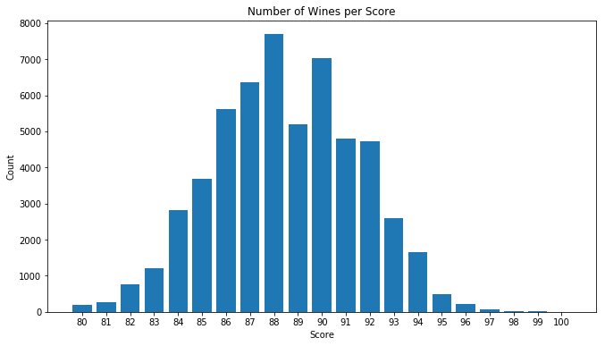

```python
# Histogram for score

points_group = reviews.groupby('points').agg('count').reset_index()
points = points_group['points'].values
count = points_group['price'].values
plt.figure(figsize=(11,6))
plt.bar(points, count)
plt.ylabel('Count')
plt.xlabel('Score')
plt.xticks(points)
plt.title('Number of Wines per Score')
```

This is similar to a standard distribution.

```
Text(0.5,1,'Number of Wines per Price Group')
```

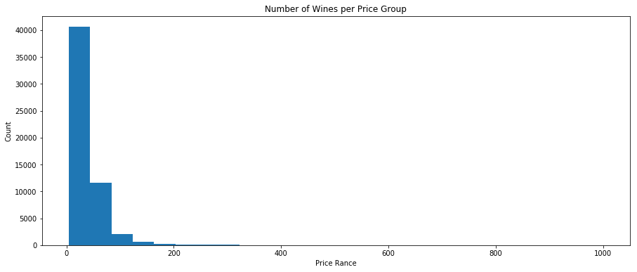

```python
# Histogram for price

plt.figure(figsize=(15,6))
plt.hist(reviews['price'], 25, (reviews['price'].min(), reviews['price'].max()), histtype = 'bar')
plt.ylabel('Count')
plt.xlabel('Price Rance')
plt.title('Number of Wines per Price Group')
```

This shows that the data is very skewed. Sampling the data will not help, as the distribution is very unbalanced. Error might be mitigated slightly by standardizing the price. However, the results will not be very accurate. The trend line between standardized price, and score will not be very smooth.

```python
# Standardize price

reviews['price'] = (reviews['price'] - reviews['price'].mean())/reviews['price'].std()
```

```
Text(0.5,1,'Price vs Points')
```

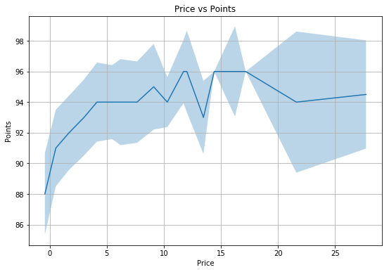

```python
# Plot line relating medain of price intervals, and mean score

price_groups = reviews.groupby(pd.cut(reviews['price'], bins=25)).agg([np.median, np.std])
price_groups = price_groups.dropna() # For price ranges which do not any value
price_groups.columns = ['points_median', 'points_std', 'price_median', 'price_std']
price_groups.reset_index()

plt.figure(figsize=(9,6))
X = price_groups['price_median']
Y = price_groups['points_median']
err = price_groups['points_std']

plt.plot(X, Y)
plt.fill_between(X, Y - err, Y + err, alpha=0.3)
plt.grid()
plt.xlabel('Price')
plt.ylabel('Points')
plt.title('Price vs Points')
```

As expected, the line is not smooth. This is attributed to incomplete data. However, it can be extrapolated that as price increases, points received increases. It is a logarithmic trend. Since there are fewer observations for the higher priced wine, the mean score is not very accurate. However the error (showed in light blue) shows that the generaly trend is that higher priced wine is better ranked.

```python
t_test = smf.ols(formula='price ~ points', data=reviews).fit()
t_test.pvalues
```

```
Intercept    0.0
points       0.0
dtype: float64
```

The pvalue < 0.05 which also proves that there is a corelation.

The graph above shows that change in points as price changes is logarithmic. Thus, the predictive model must be logarithmic.  
To make a simplify the calculations, the price was divided into 50 equal buckets and the medial price for each of the buckets was considered. Price buckets with no values were dropped.

Since the price was standardized, there were few values which were negative. To account for that, the absolute value was taken.

```
Text(0.5,1,'Price vs. Points')
```

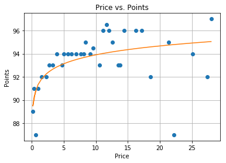

```python
# Plot trend between price and points

price_groups = reviews.groupby(pd.cut(reviews['price'], bins=50)).agg(np.median)
price_groups = price_groups.dropna()

X = price_groups['price'].values
y = price_groups['points'].values

# Account for negative standardized price
X = np.apply_along_axis(lambda x: abs(x), axis=0, arr=X)

trend = np.polyfit(np.log(X), y, 1)
y_predicted = trend[0]*np.log(X) + trend[1]

fig, ax = plt.subplots()
ax.plot(X, y, 'o', X, y_predicted)
ax.grid()
ax.set_xlabel('Price')
ax.set_ylabel('Points')
ax.set_title('Price vs. Points')
```

As seen by the scattered data points (in blue), and the trend line (in orange), there is a corelation between price and score received by a proffessional sommellier. However, the graph tends to taper at higher prices before reaching the perfect score of 100.

Therefore, it can be concluded that higher priced wine do tend to be better, but one does not need to break the bank to taste the best.

### Part 2: Chemical Traits for Good Wine

To see what qualities a wine should possess in order to have a higher quality, a dataset posted by UCIrvine[2] relating fixed acidity, volatile acidity, citric acid, residual sugar, chlorides, free sulfur dioxide, total sulfur dioxide, density, pH, sulphates, and alcohol to quality.

```python
# Read data and concatonate data

quality_red = pd.read_csv('winequality-red.csv', delimiter=';')
quality_white = pd.read_csv('winequality-white.csv', delimiter=';')

all_qualities = pd.concat([quality_red, quality_white])
all_qualities.head()
```

|  | fixed acidity | volatile acidity | citric acid | residual sugar | chlorides | free sulfur dioxide | total sulfur dioxide | density | pH | sulphates | alcohol | quality |
| --- | --- | --- | --- | --- | --- | --- | --- | --- | --- | --- | --- | --- |
| 0 | 7.4 | 0.70 | 0.00 | 1.9 | 0.076 | 11.0 | 34.0 | 0.9978 | 3.51 | 0.56 | 9.4 | 5 |
| 1 | 7.8 | 0.88 | 0.00 | 2.6 | 0.098 | 25.0 | 67.0 | 0.9968 | 3.20 | 0.68 | 9.8 | 5 |
| 2 | 7.8 | 0.76 | 0.04 | 2.3 | 0.092 | 15.0 | 54.0 | 0.9970 | 3.26 | 0.65 | 9.8 | 5 |
| 3 | 11.2 | 0.28 | 0.56 | 1.9 | 0.075 | 17.0 | 60.0 | 0.9980 | 3.16 | 0.58 | 9.8 | 6 |
| 4 | 7.4 | 0.70 | 0.00 | 1.9 | 0.076 | 11.0 | 34.0 | 0.9978 | 3.51 | 0.56 | 9.4 | 5 |

```python
all_qualities.describe()
```

|  | fixed acidity | volatile acidity | citric acid | residual sugar | chlorides | free sulfur dioxide | total sulfur dioxide | density | pH | sulphates | alcohol | quality |
| --- | --- | --- | --- | --- | --- | --- | --- | --- | --- | --- | --- | --- |
| count | 6497.000000 | 6497.000000 | 6497.000000 | 6497.000000 | 6497.000000 | 6497.000000 | 6497.000000 | 6497.000000 | 6497.000000 | 6497.000000 | 6497.000000 | 6497.000000 |
| mean | 7.215307 | 0.339666 | 0.318633 | 5.443235 | 0.056034 | 30.525319 | 115.744574 | 0.994697 | 3.218501 | 0.531268 | 10.491801 | 5.818378 |
| std | 1.296434 | 0.164636 | 0.145318 | 4.757804 | 0.035034 | 17.749400 | 56.521855 | 0.002999 | 0.160787 | 0.148806 | 1.192712 | 0.873255 |
| min | 3.800000 | 0.080000 | 0.000000 | 0.600000 | 0.009000 | 1.000000 | 6.000000 | 0.987110 | 2.720000 | 0.220000 | 8.000000 | 3.000000 |
| 25% | 6.400000 | 0.230000 | 0.250000 | 1.800000 | 0.038000 | 17.000000 | 77.000000 | 0.992340 | 3.110000 | 0.430000 | 9.500000 | 5.000000 |
| 50% | 7.000000 | 0.290000 | 0.310000 | 3.000000 | 0.047000 | 29.000000 | 118.000000 | 0.994890 | 3.210000 | 0.510000 | 10.300000 | 6.000000 |
| 75% | 7.700000 | 0.400000 | 0.390000 | 8.100000 | 0.065000 | 41.000000 | 156.000000 | 0.996990 | 3.320000 | 0.600000 | 11.300000 | 6.000000 |
| max | 15.900000 | 1.580000 | 1.660000 | 65.800000 | 0.611000 | 289.000000 | 440.000000 | 1.038980 | 4.010000 | 2.000000 | 14.900000 | 9.000000 |

To get a better understanding, the qulity score for varying traits was observed.

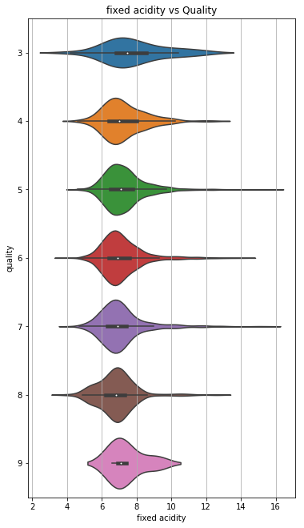

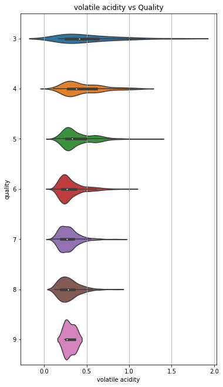

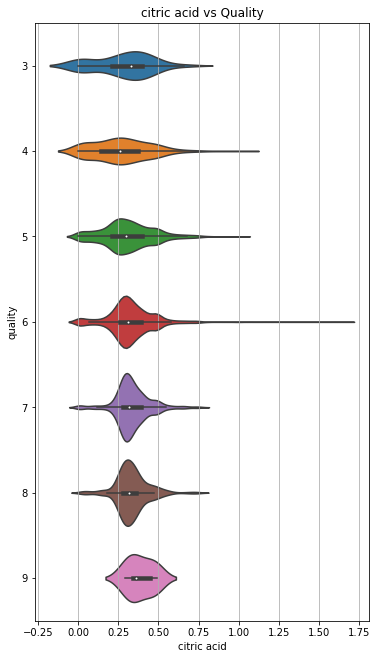

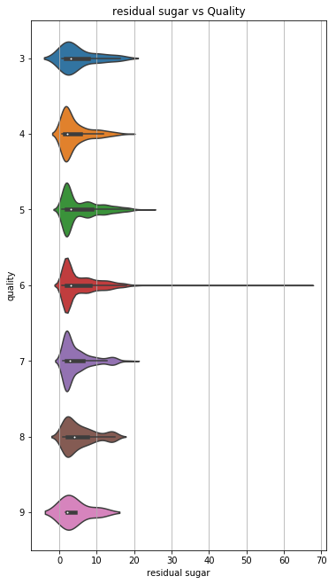

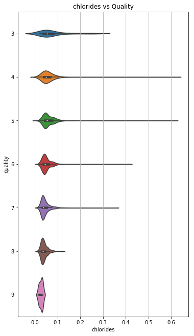

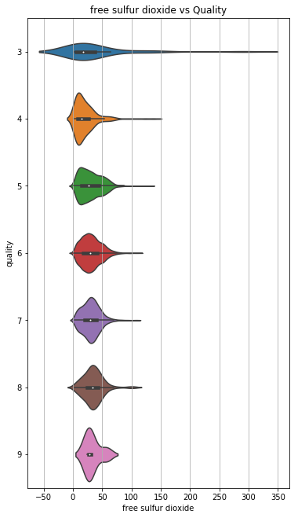

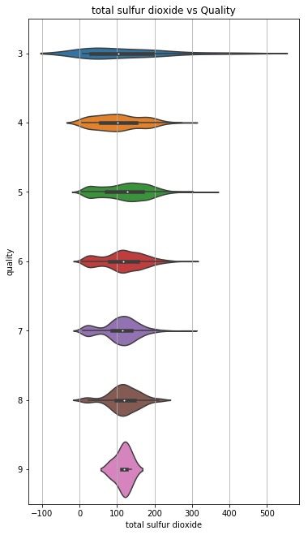

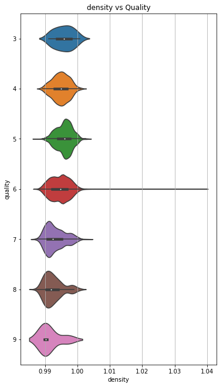

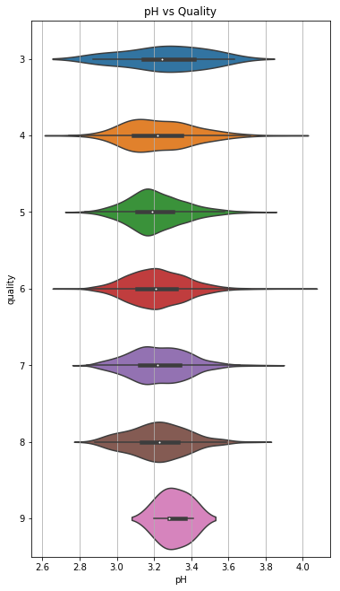

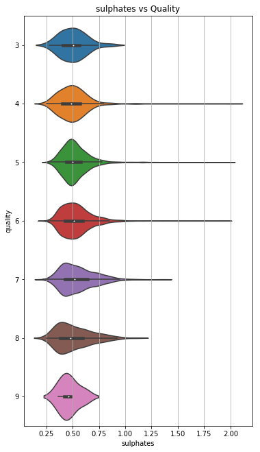

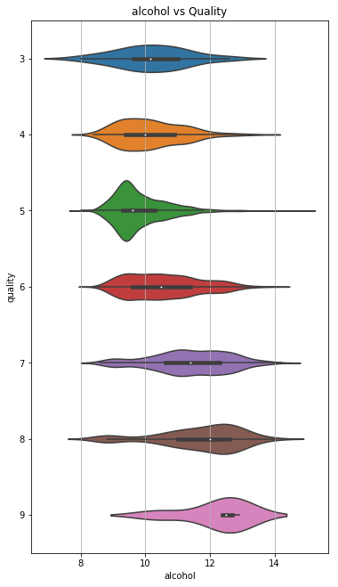

```python
# Quality for varying traits

for column in all_qualities:
    if column != 'quality':
        fig, ax = plt.subplots(figsize=(6, 11))
        ax.grid()
        sns.violinplot(x=column, y='quality', data=all_qualities, ax=ax, orient='h')
        ax.set_title("%s vs Quality" % (column))
```

As seen from the graphs, the differences are very subtle and that is not easy to isolate few independent variables.

To create an accurate model to predict which factors are important to wine, different models were trained and cross validated.

```python
# Prepare inputs

y = all_qualities['quality'].values
del all_qualities['quality']

X = all_qualities.values

X_train, X_test, y_train, y_test = train_test_split(X, y, test_size=0.33)
```

```python
# Linear Regression

reg = LinearRegression().fit(X_train, y_train)
cross_val_score(reg, X_test, y_test, cv=10)
```

```
array([ 0.21722929,  0.33032418,  0.30227365,  0.31985132,  0.21823496,
        0.1914905 ,  0.25515468,  0.2850503 ,  0.3578739 ,  0.29789551])
```

```python
# Random Forest

rf = RandomForestRegressor(n_estimators = 3000, random_state = 42).fit(X_train, y_train)
cross_val_score(rf, X_test, y_test, cv=10)
```

```
array([ 0.37129438,  0.42974475,  0.45575613,  0.43390579,  0.35251387,
        0.44897674,  0.4097711 ,  0.46487204,  0.45471571,  0.38556108])
```

The cross validation scores show that the above models are not accurate enough to draw conclusions from. Training a SVM was slow, and computationally expensive. A neural network would possibly create better results, but it is out of the scope of this project.

This could explain why wine tasting is very difficulty. To become a master sommellier, you need to pass difficult tests. Based on an article by [BusinessInsider](https://www.businessinsider.com/what-it-takes-to-become-a-master-sommelier-2015-6), there are only 229 people who have passed the exam [3].

In the mean time, you can sound educated on wine by common words used by reviewers.

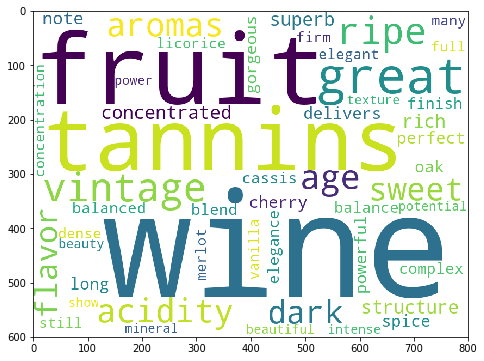

```python
# Create a word cloud

all_descriptions = pd.read_csv('winemag-data-130k-v2.csv', usecols=['description', 'points'])
all_descriptions = all_descriptions.nlargest(50, 'points')

comment_words = ''
stopwords = set(STOPWORDS)
more_stopwords = ['will','new','now','year', 'least', 'vineyard', 'years', 'drink', 'yet']
for word in more_stopwords:
    stopwords.add(word)

for _, row in all_descriptions.iterrows():
    tokens = row['description'].split()

    for words in tokens:
        comment_words = comment_words + words.lower() + ' '


wordcloud = WordCloud(width = 800, height = 600, max_words=50,
                background_color ='white',
                stopwords = stopwords,
                min_font_size = 10).generate(comment_words)
plt.figure(figsize = (8, 6))
plt.imshow(wordcloud)
```

Reference:

[1] https://www.kaggle.com/zynicide/wine-reviews

[2] https://archive.ics.uci.edu/ml/datasets/Wine+Quality

[3] https://www.businessinsider.com/what-it-takes-to-become-a-master-sommelier-2015-6